# Task # 5 - To explore Business Analytics

```
Perform ‘Exploratory Data Analysis’ on the provided dataset ‘SampleSuperstore.
```

You are the business owner of the retail firm and want to see how your company is performing. You are interested in finding out the weak areas where you can work to make more profit.

## Importing packages

```python
# Importing packages
import pandas as pd
import seaborn as sns
import matplotlib.pyplot as plt

# Comment this if the data visualisations doesn't work on your side
%matplotlib inline

plt.style.use('bmh')
```

```python
# Let's try to read from the superstore.csv
df = pd.read_csv('SampleSuperstore.csv')
```

```python
df
```

|  | Ship Mode | Segment | Country | City | State | Postal Code | Region | Category | Sub-Category | Sales | Quantity | Discount | Profit |
| --- | --- | --- | --- | --- | --- | --- | --- | --- | --- | --- | --- | --- | --- |
| 0 | Second Class | Consumer | United States | Henderson | Kentucky | 42420 | South | Furniture | Bookcases | 261.9600 | 2 | 0.00 | 41.9136 |
| 1 | Second Class | Consumer | United States | Henderson | Kentucky | 42420 | South | Furniture | Chairs | 731.9400 | 3 | 0.00 | 219.5820 |
| 2 | Second Class | Corporate | United States | Los Angeles | California | 90036 | West | Office Supplies | Labels | 14.6200 | 2 | 0.00 | 6.8714 |
| 3 | Standard Class | Consumer | United States | Fort Lauderdale | Florida | 33311 | South | Furniture | Tables | 957.5775 | 5 | 0.45 | -383.0310 |
| 4 | Standard Class | Consumer | United States | Fort Lauderdale | Florida | 33311 | South | Office Supplies | Storage | 22.3680 | 2 | 0.20 | 2.5164 |
| ... | ... | ... | ... | ... | ... | ... | ... | ... | ... | ... | ... | ... | ... |
| 9989 | Second Class | Consumer | United States | Miami | Florida | 33180 | South | Furniture | Furnishings | 25.2480 | 3 | 0.20 | 4.1028 |
| 9990 | Standard Class | Consumer | United States | Costa Mesa | California | 92627 | West | Furniture | Furnishings | 91.9600 | 2 | 0.00 | 15.6332 |
| 9991 | Standard Class | Consumer | United States | Costa Mesa | California | 92627 | West | Technology | Phones | 258.5760 | 2 | 0.20 | 19.3932 |
| 9992 | Standard Class | Consumer | United States | Costa Mesa | California | 92627 | West | Office Supplies | Paper | 29.6000 | 4 | 0.00 | 13.3200 |
| 9993 | Second Class | Consumer | United States | Westminster | California | 92683 | West | Office Supplies | Appliances | 243.1600 | 2 | 0.00 | 72.9480 |

9994 rows × 13 columns

```python
df.head()
```

|  | Ship Mode | Segment | Country | City | State | Postal Code | Region | Category | Sub-Category | Sales | Quantity | Discount | Profit |
| --- | --- | --- | --- | --- | --- | --- | --- | --- | --- | --- | --- | --- | --- |
| 0 | Second Class | Consumer | United States | Henderson | Kentucky | 42420 | South | Furniture | Bookcases | 261.9600 | 2 | 0.00 | 41.9136 |
| 1 | Second Class | Consumer | United States | Henderson | Kentucky | 42420 | South | Furniture | Chairs | 731.9400 | 3 | 0.00 | 219.5820 |
| 2 | Second Class | Corporate | United States | Los Angeles | California | 90036 | West | Office Supplies | Labels | 14.6200 | 2 | 0.00 | 6.8714 |
| 3 | Standard Class | Consumer | United States | Fort Lauderdale | Florida | 33311 | South | Furniture | Tables | 957.5775 | 5 | 0.45 | -383.0310 |
| 4 | Standard Class | Consumer | United States | Fort Lauderdale | Florida | 33311 | South | Office Supplies | Storage | 22.3680 | 2 | 0.20 | 2.5164 |

```python
df.shape
```

```
(9994, 13)
```

```python
# Let's print the columns data types.
df.info()
```

```
<class 'pandas.core.frame.DataFrame'>
RangeIndex: 9994 entries, 0 to 9993
Data columns (total 13 columns):
 #   Column        Non-Null Count  Dtype
---  ------        --------------  -----
 0   Ship Mode     9994 non-null   object
 1   Segment       9994 non-null   object
 2   Country       9994 non-null   object
 3   City          9994 non-null   object
 4   State         9994 non-null   object
 5   Postal Code   9994 non-null   int64
 6   Region        9994 non-null   object
 7   Category      9994 non-null   object
 8   Sub-Category  9994 non-null   object
 9   Sales         9994 non-null   float64
 10  Quantity      9994 non-null   int64
 11  Discount      9994 non-null   float64
 12  Profit        9994 non-null   float64
dtypes: float64(3), int64(2), object(8)
memory usage: 1015.1+ KB
```

```python
# Describing statistical information on the dataset
df.describe()
```

|  | Postal Code | Sales | Quantity | Discount | Profit |
| --- | --- | --- | --- | --- | --- |
| count | 9994.000000 | 9994.000000 | 9994.000000 | 9994.000000 | 9994.000000 |
| mean | 55190.379428 | 229.858001 | 3.789574 | 0.156203 | 28.656896 |
| std | 32063.693350 | 623.245101 | 2.225110 | 0.206452 | 234.260108 |
| min | 1040.000000 | 0.444000 | 1.000000 | 0.000000 | -6599.978000 |
| 25% | 23223.000000 | 17.280000 | 2.000000 | 0.000000 | 1.728750 |
| 50% | 56430.500000 | 54.490000 | 3.000000 | 0.200000 | 8.666500 |
| 75% | 90008.000000 | 209.940000 | 5.000000 | 0.200000 | 29.364000 |
| max | 99301.000000 | 22638.480000 | 14.000000 | 0.800000 | 8399.976000 |

```python
# Describing more statistical information on the dataset
df.describe(include='all')
```

|  | Ship Mode | Segment | Country | City | State | Postal Code | Region | Category | Sub-Category | Sales | Quantity | Discount | Profit |
| --- | --- | --- | --- | --- | --- | --- | --- | --- | --- | --- | --- | --- | --- |
| count | 9994 | 9994 | 9994 | 9994 | 9994 | 9994.000000 | 9994 | 9994 | 9994 | 9994.000000 | 9994.000000 | 9994.000000 | 9994.000000 |
| unique | 4 | 3 | 1 | 531 | 49 | NaN | 4 | 3 | 17 | NaN | NaN | NaN | NaN |
| top | Standard Class | Consumer | United States | New York City | California | NaN | West | Office Supplies | Binders | NaN | NaN | NaN | NaN |
| freq | 5968 | 5191 | 9994 | 915 | 2001 | NaN | 3203 | 6026 | 1523 | NaN | NaN | NaN | NaN |
| mean | NaN | NaN | NaN | NaN | NaN | 55190.379428 | NaN | NaN | NaN | 229.858001 | 3.789574 | 0.156203 | 28.656896 |
| std | NaN | NaN | NaN | NaN | NaN | 32063.693350 | NaN | NaN | NaN | 623.245101 | 2.225110 | 0.206452 | 234.260108 |
| min | NaN | NaN | NaN | NaN | NaN | 1040.000000 | NaN | NaN | NaN | 0.444000 | 1.000000 | 0.000000 | -6599.978000 |
| 25% | NaN | NaN | NaN | NaN | NaN | 23223.000000 | NaN | NaN | NaN | 17.280000 | 2.000000 | 0.000000 | 1.728750 |
| 50% | NaN | NaN | NaN | NaN | NaN | 56430.500000 | NaN | NaN | NaN | 54.490000 | 3.000000 | 0.200000 | 8.666500 |
| 75% | NaN | NaN | NaN | NaN | NaN | 90008.000000 | NaN | NaN | NaN | 209.940000 | 5.000000 | 0.200000 | 29.364000 |
| max | NaN | NaN | NaN | NaN | NaN | 99301.000000 | NaN | NaN | NaN | 22638.480000 | 14.000000 | 0.800000 | 8399.976000 |

```python
# Let's try to read from the superstore.csv
pd.set_option('display.max_columns', 20)
pd.set_option('display.max_rows', 5)
# Let's try to give it a go with the new setting.
df
```

|  | Ship Mode | Segment | Country | City | State | Postal Code | Region | Category | Sub-Category | Sales | Quantity | Discount | Profit |
| --- | --- | --- | --- | --- | --- | --- | --- | --- | --- | --- | --- | --- | --- |
| 0 | Second Class | Consumer | United States | Henderson | Kentucky | 42420 | South | Furniture | Bookcases | 261.96 | 2 | 0.0 | 41.9136 |
| 1 | Second Class | Consumer | United States | Henderson | Kentucky | 42420 | South | Furniture | Chairs | 731.94 | 3 | 0.0 | 219.5820 |
| ... | ... | ... | ... | ... | ... | ... | ... | ... | ... | ... | ... | ... | ... |
| 9992 | Standard Class | Consumer | United States | Costa Mesa | California | 92627 | West | Office Supplies | Paper | 29.60 | 4 | 0.0 | 13.3200 |
| 9993 | Second Class | Consumer | United States | Westminster | California | 92683 | West | Office Supplies | Appliances | 243.16 | 2 | 0.0 | 72.9480 |

9994 rows × 13 columns

```python
# Let's try to rename the column.
df.columns = [ 'Ship Mode', 'Segment' , 'Country', 'City', 'State', 'PostalCode', 'Region', 'Category', 'Sub-Category' , 'Sales', 'Quantity', 'Discount', 'Profit']
df
```

|  | Ship Mode | Segment | Country | City | State | PostalCode | Region | Category | Sub-Category | Sales | Quantity | Discount | Profit |
| --- | --- | --- | --- | --- | --- | --- | --- | --- | --- | --- | --- | --- | --- |
| 0 | Second Class | Consumer | United States | Henderson | Kentucky | 42420 | South | Furniture | Bookcases | 261.96 | 2 | 0.0 | 41.9136 |
| 1 | Second Class | Consumer | United States | Henderson | Kentucky | 42420 | South | Furniture | Chairs | 731.94 | 3 | 0.0 | 219.5820 |
| ... | ... | ... | ... | ... | ... | ... | ... | ... | ... | ... | ... | ... | ... |
| 9992 | Standard Class | Consumer | United States | Costa Mesa | California | 92627 | West | Office Supplies | Paper | 29.60 | 4 | 0.0 | 13.3200 |
| 9993 | Second Class | Consumer | United States | Westminster | California | 92683 | West | Office Supplies | Appliances | 243.16 | 2 | 0.0 | 72.9480 |

9994 rows × 13 columns

```python
# Let's create a class named `display_all`, by which later we call on the next command.
def display_all(df):
    with pd.option_context("display.max_rows", 1000, "display.max_columns", 1000):
        display(df)
```

```python
display_all(df.head(10).T)
```

|  | 0 | 1 | 2 | 3 | 4 | 5 | 6 | 7 | 8 | 9 |
| --- | --- | --- | --- | --- | --- | --- | --- | --- | --- | --- |
| Ship Mode | Second Class | Second Class | Second Class | Standard Class | Standard Class | Standard Class | Standard Class | Standard Class | Standard Class | Standard Class |
| Segment | Consumer | Consumer | Corporate | Consumer | Consumer | Consumer | Consumer | Consumer | Consumer | Consumer |
| Country | United States | United States | United States | United States | United States | United States | United States | United States | United States | United States |
| City | Henderson | Henderson | Los Angeles | Fort Lauderdale | Fort Lauderdale | Los Angeles | Los Angeles | Los Angeles | Los Angeles | Los Angeles |
| State | Kentucky | Kentucky | California | Florida | Florida | California | California | California | California | California |
| PostalCode | 42420 | 42420 | 90036 | 33311 | 33311 | 90032 | 90032 | 90032 | 90032 | 90032 |
| Region | South | South | West | South | South | West | West | West | West | West |
| Category | Furniture | Furniture | Office Supplies | Furniture | Office Supplies | Furniture | Office Supplies | Technology | Office Supplies | Office Supplies |
| Sub-Category | Bookcases | Chairs | Labels | Tables | Storage | Furnishings | Art | Phones | Binders | Appliances |
| Sales | 261.96 | 731.94 | 14.62 | 957.577 | 22.368 | 48.86 | 7.28 | 907.152 | 18.504 | 114.9 |
| Quantity | 2 | 3 | 2 | 5 | 2 | 7 | 4 | 6 | 3 | 5 |
| Discount | 0 | 0 | 0 | 0.45 | 0.2 | 0 | 0 | 0.2 | 0.2 | 0 |
| Profit | 41.9136 | 219.582 | 6.8714 | -383.031 | 2.5164 | 14.1694 | 1.9656 | 90.7152 | 5.7825 | 34.47 |

```python
display_all(df.describe(include='all').T)
```

|  | count | unique | top | freq | mean | std | min | 25% | 50% | 75% | max |
| --- | --- | --- | --- | --- | --- | --- | --- | --- | --- | --- | --- |
| Ship Mode | 9994 | 4 | Standard Class | 5968 | NaN | NaN | NaN | NaN | NaN | NaN | NaN |
| Segment | 9994 | 3 | Consumer | 5191 | NaN | NaN | NaN | NaN | NaN | NaN | NaN |
| Country | 9994 | 1 | United States | 9994 | NaN | NaN | NaN | NaN | NaN | NaN | NaN |
| City | 9994 | 531 | New York City | 915 | NaN | NaN | NaN | NaN | NaN | NaN | NaN |
| State | 9994 | 49 | California | 2001 | NaN | NaN | NaN | NaN | NaN | NaN | NaN |
| PostalCode | 9994 | NaN | NaN | NaN | 55190.4 | 32063.7 | 1040 | 23223 | 56430.5 | 90008 | 99301 |
| Region | 9994 | 4 | West | 3203 | NaN | NaN | NaN | NaN | NaN | NaN | NaN |
| Category | 9994 | 3 | Office Supplies | 6026 | NaN | NaN | NaN | NaN | NaN | NaN | NaN |
| Sub-Category | 9994 | 17 | Binders | 1523 | NaN | NaN | NaN | NaN | NaN | NaN | NaN |
| Sales | 9994 | NaN | NaN | NaN | 229.858 | 623.245 | 0.444 | 17.28 | 54.49 | 209.94 | 22638.5 |
| Quantity | 9994 | NaN | NaN | NaN | 3.78957 | 2.22511 | 1 | 2 | 3 | 5 | 14 |
| Discount | 9994 | NaN | NaN | NaN | 0.156203 | 0.206452 | 0 | 0 | 0.2 | 0.2 | 0.8 |
| Profit | 9994 | NaN | NaN | NaN | 28.6569 | 234.26 | -6599.98 | 1.72875 | 8.6665 | 29.364 | 8399.98 |

```
count     9994.000000
mean       229.858001
             ...
75%        209.940000
max      22638.480000
Name: Sales, Length: 8, dtype: float64
```

```
C:\Users\santosh sharma\Anaconda3\lib\site-packages\seaborn\distributions.py:218: MatplotlibDeprecationWarning:
The 'normed' kwarg was deprecated in Matplotlib 2.1 and will be removed in 3.1. Use 'density' instead.
  color=hist_color, **hist_kws)
```

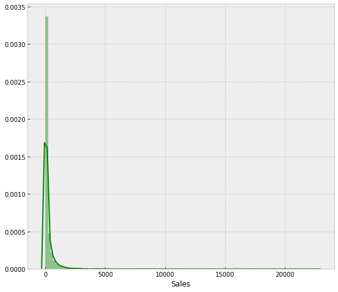

```python
print(df['Sales'].describe())
plt.figure(figsize=(9, 8))
sns.distplot(df['Sales'], color='g', bins=100, hist_kws={'alpha': 0.4});
```

To do so lets first list all the types of our data from our dataset and take only the numerical ones:

```python
list(set(df.dtypes.tolist()))
```

```
[dtype('int64'), dtype('float64'), dtype('O')]
```

```python
df_num = df.select_dtypes(include = ['float64', 'int64'])
df_num.head()
```

|  | PostalCode | Sales | Quantity | Discount | Profit |
| --- | --- | --- | --- | --- | --- |
| 0 | 42420 | 261.9600 | 2 | 0.00 | 41.9136 |
| 1 | 42420 | 731.9400 | 3 | 0.00 | 219.5820 |
| 2 | 90036 | 14.6200 | 2 | 0.00 | 6.8714 |
| 3 | 33311 | 957.5775 | 5 | 0.45 | -383.0310 |
| 4 | 33311 | 22.3680 | 2 | 0.20 | 2.5164 |

## Data Visualization

To check missing values

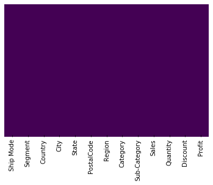

```python
sns.heatmap(df.isnull(),cbar=False,yticklabels=False,cmap = 'viridis')
```

Now lets plot them all

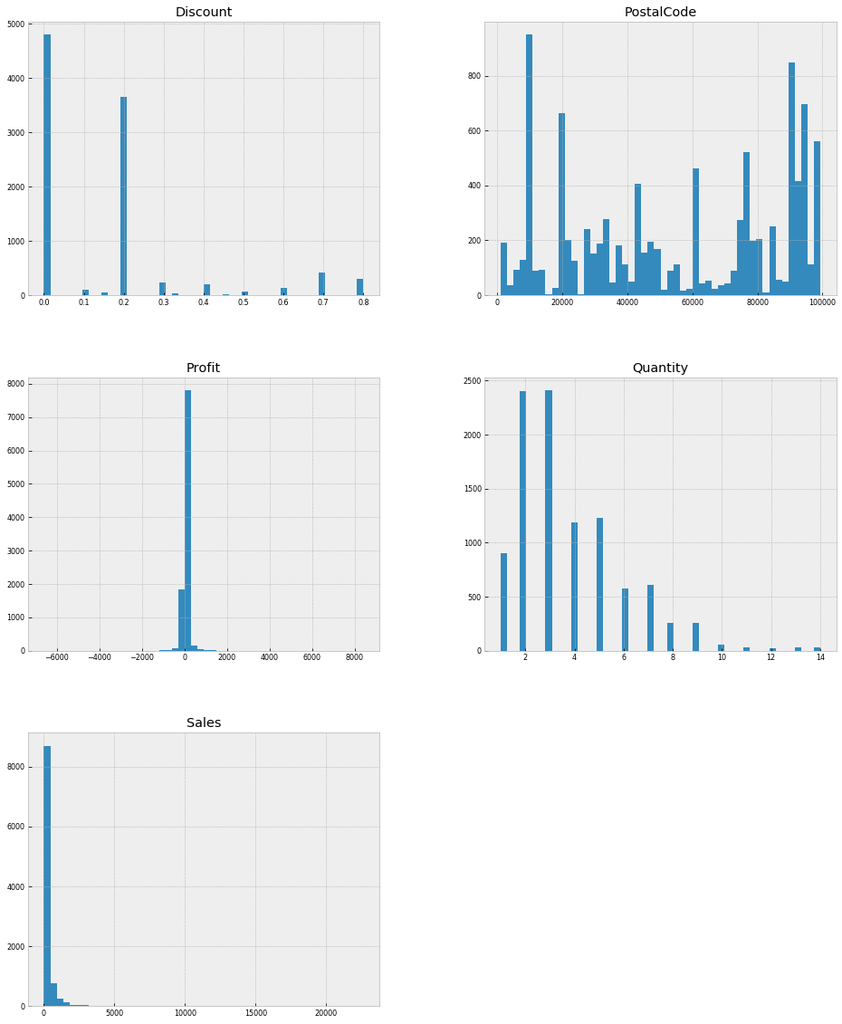

```python
df_num.hist(figsize=(16, 20), bins=50, xlabelsize=8, ylabelsize=8); # ; avoid having the matplotlib verbose informations
```

Now we'll try to find which features are strongly correlated with Sales. We'll store them in a var called golden_features_list. We'll reuse our df_num dataset to do so.

```python
df_num_corr = df_num.corr()['Sales'][:-1] # -1 because the latest row is SalePrice
golden_features_list = df_num_corr[abs(df_num_corr) > 0.5].sort_values(ascending=False)
print("There is {} strongly correlated values with Sales:\n{}".format(len(golden_features_list), golden_features_list))
```

```
There is 1 strongly correlated values with Sales:
Sales    1.0
Name: Sales, dtype: float64
```

```
1. Plot the numerical features and see which ones have very few or explainable outliers
2. Remove the outliers from these features and see which one can have a good correlation without their outliers
```

Btw, correlation by itself does not always explain the relationship between data so ploting them could even lead us to new insights and in the same manner, check that our correlated values have a linear relationship to the Sales.

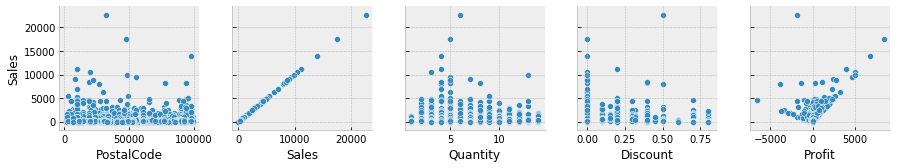

```python
for i in range(0, len(df_num.columns), 5):
    sns.pairplot(data=df_num,
                x_vars=df_num.columns[i:i+5],
                y_vars=['Sales'])
```

## Feature to feature relationship

Trying to plot all the numerical features in a seaborn pairplot will take us too much time and will be hard to interpret. We can try to see if some variables are linked between each other and then explain their relation with common sense

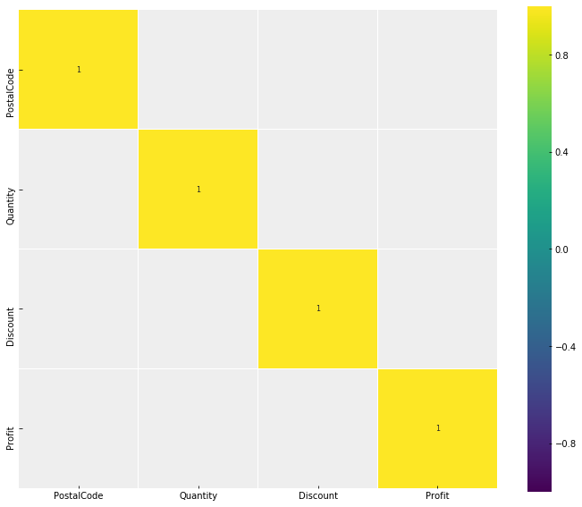

```python
corr = df_num.drop('Sales', axis=1).corr() # We already examined SalePrice correlations
plt.figure(figsize=(12, 10))

sns.heatmap(corr[(corr >= 0.5) | (corr <= -0.4)],
            cmap='viridis', vmax=1.0, vmin=-1.0, linewidths=0.1,
            annot=True, annot_kws={"size": 8}, square=True);
```

## To check correlation

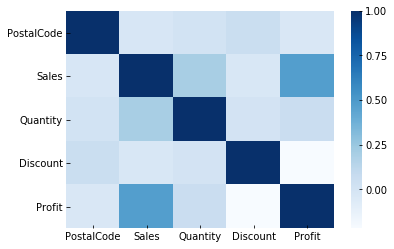

```python
plt.figure(figsize=(6,4))
sns.heatmap(df.corr(),cmap='Blues',annot=False)
```

Dark shades represents positive correlation while lighter shades represents negative correlation. If you set annot=True, you'll get values by which features are correlated to each other in grid-cells

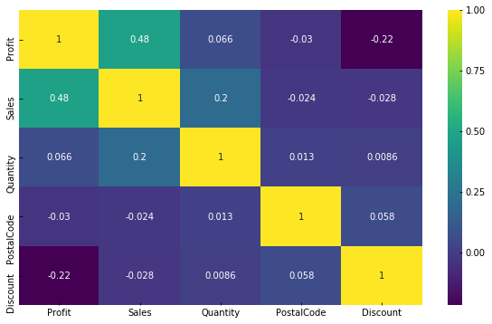

```python
#Quality correlation matrix
k = 12 #number of variables for heatmap
cols = df.corr().nlargest(k, 'Profit')['Profit'].index
cm = df[cols].corr()
plt.figure(figsize=(10,6))
sns.heatmap(cm, annot=True, cmap = 'viridis')
```

## And finally lets look at their distribution

[figure not shown]

```python
fig, axes = plt.subplots(round(len(df_num.columns) / 3), 3, figsize=(12, 30))

for i, ax in enumerate(fig.axes):
    if i < len(df_num.columns):
        ax.set_xticklabels(ax.xaxis.get_majorticklabels(), rotation=45)
        sns.countplot(x=df_num.columns[i], alpha=0.7, data=df_num, ax=ax)

fig.tight_layout()
```